# Coursework 2 Part 1

**Replace CID in the file name with your CID**

# Outline

- Task 1: Classification with a Convolutional Neural Network
  - (1.1)
  - (1.2)
- Task 2: Dimensionality Reduction with Non-Negative Matrix Tri-Factorisation
  - (2.1)
  - (2.2)

# Task 1: Classification with a Convolutional Neural Network (index)

```python
# import useful packages
import numpy as np
import matplotlib.pyplot as plt
import pandas as pd
import torch
from torch.nn import Sequential, CrossEntropyLoss, Conv1d, MaxPool1d, Flatten, Linear, ReLU, Softmax, Parameter, Dropout
from torch.utils.data import TensorDataset, DataLoader
import seaborn as sns

# set global config for matplotlib to make plots readable
SMALL_SIZE = 12
MEDIUM_SIZE = 16
BIGGER_SIZE = 20

plt.rc('font', size=SMALL_SIZE)          # controls default text sizes
plt.rc('axes', titlesize=BIGGER_SIZE)     # fontsize of the axes title
plt.rc('axes', labelsize=MEDIUM_SIZE)    # fontsize of the x and y labels
plt.rc('xtick', labelsize=SMALL_SIZE)    # fontsize of the tick labels
plt.rc('ytick', labelsize=SMALL_SIZE)    # fontsize of the tick labels
plt.rc('legend', fontsize=SMALL_SIZE)    # legend fontsize
plt.rc('figure', titlesize=BIGGER_SIZE)  # fontsize of the figure title

rng = np.random.default_rng(0)
```

First we load the data and covert the non-numerical column(Trial Type) to number

```python
# load data
data = pd.read_csv("neural_activity.csv")

# show the shape of the data
print("train data shape: ", data.shape)

# Map labels
label_map = {'R': 0, 'L': 1, 'F': 2, 'B': 3}
data['Trial Type'] = data['Trial Type'].map(label_map)

data.head()
```

```
train data shape:  (3200, 203)
```

|  | Count at t=1 | Count at t=2 | Count at t=3 | Count at t=4 | Count at t=5 | Count at t=6 | Count at t=7 | Count at t=8 | Count at t=9 | Count at t=10 | ... | Count at t=194 | Count at t=195 | Count at t=196 | Count at t=197 | Count at t=198 | Count at t=199 | Count at t=200 | Brain Region Index | Trial Index | Trial Type |
| --- | --- | --- | --- | --- | --- | --- | --- | --- | --- | --- | --- | --- | --- | --- | --- | --- | --- | --- | --- | --- | --- |
| 0 | 25 | 25 | 26 | 27 | 27 | 28 | 29 | 30 | 31 | 32 | ... | 64 | 66 | 67 | 69 | 71 | 72 | 73 | 1 | 1 | 3 |
| 1 | 68 | 68 | 69 | 69 | 70 | 71 | 71 | 72 | 72 | 73 | ... | 38 | 37 | 37 | 36 | 35 | 35 | 33 | 1 | 2 | 2 |
| 2 | 30 | 29 | 29 | 29 | 29 | 29 | 29 | 30 | 30 | 31 | ... | 33 | 32 | 31 | 30 | 29 | 28 | 27 | 1 | 3 | 1 |
| 3 | 24 | 25 | 26 | 28 | 29 | 31 | 32 | 35 | 37 | 39 | ... | 94 | 93 | 91 | 90 | 88 | 86 | 84 | 1 | 4 | 0 |
| 4 | 59 | 59 | 59 | 59 | 59 | 58 | 58 | 58 | 58 | 59 | ... | 37 | 34 | 33 | 31 | 29 | 28 | 26 | 1 | 5 | 2 |

5 rows × 203 columns

From the head of data, we can see there are 203 columns, including the time step features(index 0-199), Brain Region Index(column index 200), Trial Index(column index 201), and Trial Type(column index 202)

In this task, we want the data convert to ($N^{\text{trials}} \times N^{\text{regions}} \times p$) tensor, and take the $N^{\text{trials}}$ as sample numbers and $N^{\text{regions}}$ as channel numbers, $p$ as the data features dimension. To create such tensor we need to reshape our data matrix. However, from the head of data, we can see that the samples are sorted by Brain Region Index first and then Trial Index, so we need to reshape the data into ($N^{\text{regions}} \times N^{\text{trials}} \times p$) first and then transpose the first two dimensions(regions and trials). Finally we can get the ($N^{\text{trials}} \times N^{\text{regions}} \times p$) tensor.

Use normalised data for all the tasks, using the min-max normalisation seen in the Week 8 notebook, since the count at each time step is a non-negative number. In the previous coursework, we use the mean and std of train to standardise both train and test set, but in this coursework, wo don't use the min and max value of train set because when the min value of train set is smaller than the min value of test set, there might be negative values in the test set after normalize even though there is no negative value in this specific case.

To make sure the each sample's region is the same, we print one sample, we can see that the sample's -2nd column(trial index) is the same, and the last column(trial type) is also the same. This indicates that there is no disorder.

Then we split the data into train and test set.

And take the first 200 columns(time step features) as X, and take the last column(trial type) as y. Since each trial has a fixed trial type, so the squeeze the regions dimension(take the first region's value)

```python
def normalize_nmf(X):
    """
    Globally normalise features.

    Parameters:
        X (np.array): Feature matrix.

    Returns:b
        X_norm (np.array): Normalised feature matrix
    """

    X_norm = (X- np.min(X)) / (np.max(X) - np.min(X))  ## <-- SOLUTION
    return X_norm

X_norm = normalize_nmf(np.asarray(data.iloc[:, :200])) # same as week 8 note
# concate to replace the original data
data_np = np.hstack([X_norm, np.asarray(data.iloc[:, 200:203])])
```

```python
# The number of brain regions and trials
N_Brain_Region = data["Brain Region Index"].unique().shape[0]
N_Trial_Index = data["Trial Index"].unique().shape[0]

# Reshape the data to N_trial x N_region x p
data_reshaped = data_np.reshape(N_Brain_Region, N_Trial_Index, -1).transpose((1, 0, 2))
print("reshaped data sample: ", data_reshaped[0, :, :])

# Split the features and labels
X = data_reshaped[:, :, :200]
y = data_reshaped[:, 0, :-1]


# Split train and test data
test_idx = [56, 30, 42, 63, 7, 66, 2, 77, 78, 13, 39, 61, 5, 67, 70, 46]
all_idx = np.arange(len(data_reshaped))
train_idx = np.setdiff1d(all_idx, test_idx)
test_data = data_reshaped[test_idx]
train_data = data_reshaped[train_idx]

# Split the features and labels
X_train = train_data[:, :, :200]
X_test = test_data[:, :, :200]
y_train = train_data[:, 0, -1]
y_test = test_data[:, 0, -1]

print(X_train.shape)
print(y_train.shape)
print(X_test.shape)
print(y_test.shape)
```

```
reshaped data sample:  [[ 0.13368984  0.13368984  0.13903743 ...  1.          1.
   3.        ]
 [ 0.30481283  0.31016043  0.31016043 ...  2.          1.
   3.        ]
 [ 0.21925134  0.21925134  0.22459893 ...  3.          1.
   3.        ]
 ...
 [ 0.          0.          0.         ... 38.          1.
   3.        ]
 [ 0.          0.          0.         ... 39.          1.
   3.        ]
 [ 0.          0.          0.         ... 40.          1.
   3.        ]]
(64, 40, 200)
(64,)
(16, 40, 200)
(16,)
```

Some may concern there will be a data leakage if we normalize before split, so I write the non-leakage version in comment.

```python
# # The number of brain regions and trials
# N_Brain_Region = data["Brain Region Index"].unique().shape[0]
# N_Trial_Index = data["Trial Index"].unique().shape[0]

# # Reshape the data to N_trial x N_region x p
# data_reshaped = np.asarray(data).reshape(N_Brain_Region, N_Trial_Index, -1).transpose((1, 0, 2))
# print("reshaped data sample: ", data_reshaped[0, :, :])

# # Split the features and labels
# X = data_reshaped[:, :, :200]
# y = data_reshaped[:, 0, :-1]


# # Split train and test data
# test_idx = [56, 30, 42, 63, 7, 66, 2, 77, 78, 13, 39, 61, 5, 67, 70, 46]
# all_idx = np.arange(len(data_reshaped))
# train_idx = np.setdiff1d(all_idx, test_idx)
# test_data = data_reshaped[test_idx]
# train_data = data_reshaped[train_idx]

# # Split the features and labels
# X_train = train_data[:, :, :200]
# X_test = test_data[:, :, :200]
# y_train = train_data[:, 0, -1]
# y_test = test_data[:, 0, -1]

# train_max, train_min = X_train.max(), X_train.min()
# X_train = (X_train - train_min) / (train_max - train_min)
# X_test = (X_test - train_min) / (train_max - train_min)

# print(X_train.shape)
# print(y_train.shape)
# print(X_test.shape)
# print(y_test.shape)
```

## (1.1) (index)

Here we build a PyTorch CNN model

- `c_in` and `c_out` (equal to `n_filters`) represent the number of input and output channels (respectively).
- `i` and `o` denote the length of the input and output signals (respectively).
- `k` is the length of the convolving kernel/filter.
- `p` is the total number of zero-padding pixels added to the input (padding).
- `s` is the number of pixels the kernel shifts per step (stride).

For a convolutional (or max pool) layer, the input and output lengths are related as follows:

$$o=\left\lfloor\frac{i+p-k}{s}\right\rfloor +1$$ (Note the use of the floor symbol, denoted as $\lfloor x\rfloor $, which represents the greatest integer less than or equal to a real number $x$).

The CNN architecture in the task is:

- a 1-dimensional convolutional layer with 8 filters, kernel size = 16
- a ReLU activation function
- a max-pooling layer with window size = 16 and stride = 4
- a flatten layer
- dropout with dropout rate = 0.8
- linear layer connecting the flatten layer to the 4 output units.

In this task, there is no padding and the convolution layer's stride is 1(default in pytorch), so `p` is 0 and `s` is 1, so `l_out_conv = x_train.shape[2] - k + 1`

The output of convolution layer is the input of maxpool layer regardless to relu, so `l_out_pool = (l_out_conv - pool_size) // stride_pool + 1`

The tensor after maxpool is flattened, so the input dimension of the linear layer is `l_in_linear = n_filters * l_out_pool`

Here we use `CrossEntropyLoss` as our loss function and `Adam` as our optimiser.

```python
def get_model(x_train, n_filters=8, k=16, pool_size=16, stride_pool=4, classes=[0, 1, 2, 3]):
    """
    CNN model in PyTorch:
    - Layers are Conv1d(+ReLU), MaxPool1d, Flatten and Linear.
    - It features an Adam optimiser and CrossEntropyLoss criterion.

    Parameters:
        x_train (np.ndarray): Training data
        n_filters (int): Number of filters to be used in the convolutional layer
        k (int): Kernel size in the convolutional layer
        pool_size (int): MaxPool1d window size
        stride_pool (int): Stride of the MaxPool1d sliding window
        classes (List): Output classes

    Returns:
        Model, criterion and optimiser.

    """

    l_out_conv = x_train.shape[2] - k + 1 # Length after Conv1d (note that the stride is 1)
    l_out_pool = (l_out_conv - pool_size) // stride_pool + 1 # Length after MaxPool1d
    l_in_linear = n_filters * l_out_pool # Size before Linear layer

    model = Sequential(
        Conv1d(x_train.shape[1], n_filters, kernel_size=k),
        ReLU(),
        MaxPool1d(kernel_size=pool_size, stride=stride_pool),
        Flatten(),
        Dropout(p=0.8),
        Linear(l_in_linear, len(classes)),
    )

    criterion = CrossEntropyLoss()
    optimiser = torch.optim.Adam(model.parameters())

    return model, criterion, optimiser
```

Before training, we first convert our NumPy arrays into tensors. These are then wrapped into `TensorDataset` objects, which help structure the data for training and validation and testing. To efficiently load and iterate through batches of data, we use PyTorch's `DataLoader`.

```python
# Numpy arrays to PyTorch tensors
X_train_tensor = torch.tensor(X_train, dtype=torch.float32)
X_test_tensor = torch.tensor(X_test, dtype=torch.float32)
y_train_tensor = torch.tensor(y_train, dtype=torch.long)
y_test_tensor = torch.tensor(y_test, dtype=torch.long)

# Creating training and validation datasets
train_dataset = TensorDataset(X_train_tensor, y_train_tensor.squeeze())
test_dataset = TensorDataset(X_test_tensor, y_test_tensor.squeeze())

# Creating corresponding DataLoaders
train_loader = DataLoader(train_dataset, batch_size=16) # didn't set the shuffle argument because it is not specified in coursework, so use default value
tset_loader = DataLoader(test_dataset, batch_size=16)
```

Set the seed and initiate the model, loss function and optimiser. And then check the model's layers.

```python
# Set seed
torch.manual_seed(10)

# Create model, loss function and optimiser
model_CNN, criterion, optimiser = get_model(X_train_tensor)
print(model_CNN)
```

```
Sequential(
  (0): Conv1d(40, 8, kernel_size=(16,), stride=(1,))
  (1): ReLU()
  (2): MaxPool1d(kernel_size=16, stride=4, padding=0, dilation=1, ceil_mode=False)
  (3): Flatten(start_dim=1, end_dim=-1)
  (4): Dropout(p=0.8, inplace=False)
  (5): Linear(in_features=344, out_features=4, bias=True)
)
```

Then we implement the train loop. For each epoch, after the backpropagation and update of the weights, we also use evaluate mode to compute a loss on train set, and record it, and print it every 10 epochs.

```python
def training_loop(train_loader, num_epochs=100):
    """
    Training loop.

    Parameters:
        train_loader (torch.utils.data.DataLoader): Training DataLoader
        num_epochs (int): number of epochs

    Returns:
        Model, criterion and optimiser and train_loss list.

    """
    train_loss = []
    tr_loss_list = []

    for epoch in range(num_epochs):
        tr_loss = 0.0

        # Training
        model_CNN.train()
        for inputs, labels in train_loader:
            optimiser.zero_grad() # Setting gradients to zero
            outputs = model_CNN(inputs)
            loss = criterion(outputs, labels)
            tr_loss += loss.item()
            loss.backward() # Computes gradients of the loss
            optimiser.step() # Optimisation step (parameters are updated)
        tr_loss_list.append(tr_loss / len(train_loader))

        model_CNN.eval()
        with torch.no_grad():
            train_out = model_CNN(X_train_tensor)
            epoch_loss = criterion(train_out, y_train_tensor).item()
            train_loss.append(epoch_loss)

        if (epoch + 1) % 10 == 0 or epoch == 0:
            print(f'Epoch {epoch + 1}/{num_epochs}, Evaluate loss(eval mode) on Training set: {epoch_loss}, Accumulated loss(train mode) on Training set: {tr_loss / len(train_loader)}')

    return train_loss, tr_loss_list
```

Train the model and monitor the loss

```python
# Train
train_loss, tr_loss_list = training_loop(train_loader=train_loader)
```

[output not shown]

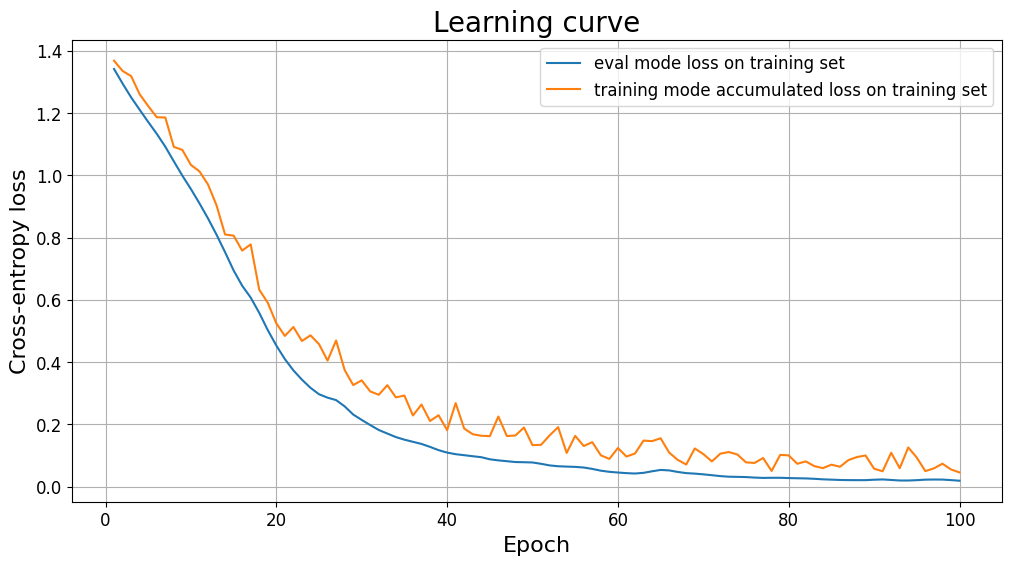

```python
fig, ax = plt.subplots(figsize=(12, 6))
ax.plot(range(1, 100 + 1), train_loss, label='eval mode loss on training set')
ax.plot(range(1, 100 + 1), tr_loss_list, label='training mode accumulated loss on training set')
ax.set(title="Learning curve", xlabel = "Epoch", ylabel = "Cross-entropy loss")
ax.grid(True)
ax.legend()
plt.show()
```

From the graph, the Cross entropy loss keeps decreasing over epochs, and he decline was rapid in the first 30 epochs, then tend to be flat, finally it reaches $1.79 \times 10^{-2}$ which is low.

Next, we want to see the hard classification and its accuracy on train set and test set. Because we assign the class with the highest probability as the class predicted by the model and the biggest logits implies the biggest probability after softmax:

$$ P(y = c \mid \mathbf{a}) = \frac{\exp(a_c)}{\sum_{q=1}^{Q}\exp(a_q)} $$

So we can directly apply `argmax` on logits.

Then calculate the accuracy on train and test set.

```python
model_CNN.eval()
with torch.no_grad():
    # Training accuracy
    train_preds = torch.argmax(model_CNN(X_train_tensor), dim=1)
    train_acc = (train_preds == y_train_tensor).float().mean()

    # Test accuracy
    test_preds = torch.argmax(model_CNN(X_test_tensor), dim=1)
    test_acc = (test_preds == y_test_tensor).float().mean()

print(f'Training accuracy: {train_acc * 100}%')
print(f'Test accuracy: {test_acc * 100}%')
```

```
Training accuracy: 100.0%
Test accuracy: 100.0%
```

The accuracy of train and test set are both 100%, which means the model not only learnt how to classify the neural activity patterns well, but also avoid the overfitting because the model's preform on the unseen data is as good as the training data.

The dropout with high dropout rate (0.8) can effectively avoid the overfitting because it set some activation of the model to 0 which act a regularization role on the model. In other views, by ignoring some neurons, every epoch is training a sub neural network with smaller scale of parameters and it prevents neurons from coadapting too much.

Moreover, the model treats brain regions as input channels, allowing convolutional filters to learn temporal patterns that shared across regions.

## (1.2) (index)

```python
# Set model to training mode
model_CNN.train()

Q = 4
N_test = len(test_idx)
all_probs = torch.zeros(10, N_test, Q)

with torch.no_grad():
    for i in range(10):
        logits = model_CNN(X_test_tensor)
        probs = torch.softmax(logits, dim=1)
        all_probs[i] = probs
```

In training mode, dropout is active at prediction time, so each forward pass random activations(80%) to 0. As a result, the predicted class probabilities for the same test sample are no longer deterministic and change across the 10 runs.

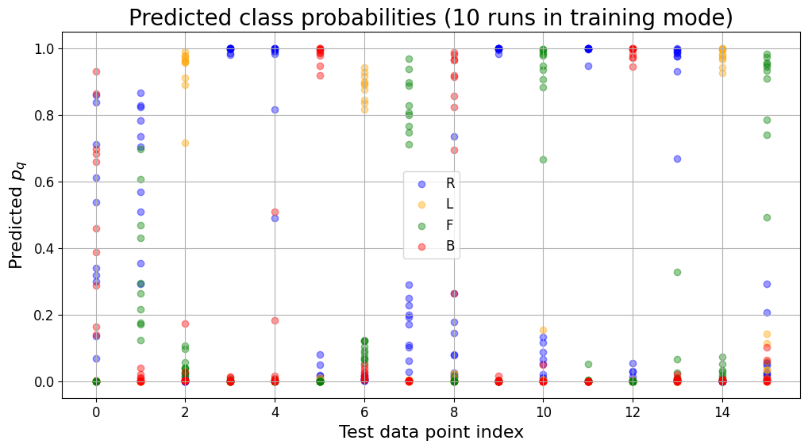

```python
# Plot predicted probabilities
class_labels = ['R', 'L', 'F', 'B']
colors = ['blue', 'orange', 'green', 'red']

plt.figure(figsize=(12, 6))
for q in range(Q):
    for run in range(10):
        x_vals = np.arange(N_test)
        y_vals = all_probs[run, :, q]
        plt.scatter(x_vals, y_vals, c=colors[q], alpha=0.4,
                    label=class_labels[q] if run == 0 else None)

plt.xlabel('Test data point index')
plt.ylabel('Predicted $p_q$')
plt.title('Predicted class probabilities (10 runs in training mode)')
plt.grid(True)
plt.legend()
plt.show()
```

In the graph, test data whose probability of one class clustered close to 1 and the others remain close to 0 are classified stably even under dropout perturbations. By contrast, a larger spread or overlap between classes means there is a greater uncertainty, which means that the sample lies closer to a decision boundary.

# Task 2: Dimensionality Reduction with Non-Negative Matrix Tri-Factorisation (index)

First set generator seed 0 for reproducibility

```python
rng = np.random.default_rng(0)
```

## (2.1) (index)

In this task, the data matrix is $\mathbf{X}_{N\times p}$, where $N=3200$, and $p=200$, so we directly normalize the original data. Since this is a dimensionality reduction task, we don't need to split a train and test set.

NMF learns a $\mathbf{\hat{X}}^{\text{NMF}}_{N\times p}$ of a non negative data matrix $\mathbf{X}_{N\times p}$ where

$$ \mathbf{X}_{N\times p} \approx \mathbf{\hat{X}}^{\text{NMF}}_{N\times p} = \mathbf{W}_{N\times r} \mathbf{H}_{r\times p} $$

The matrix $\mathbf{W}_{N\times r}$ contains the non-negative coeﬀicients expressing the data $\mathbf{x}^{(i)}$ as a linear combination of the vectors in $\mathbf{H}_{r\times p}$

To minimise the difference of $\mathbf{\hat{X}}^{\text{NMF}}_{N\times p}$ and $\mathbf{X}_{N\times p}$, we use the normalised squared Euclidean distance:

$$ \frac{\|\mathbf{X}_{N\times p} - \mathbf{\hat{X}}^{\text{NMF}}_{N\times p}\|^2}{\|\mathbf{X}_{N\times p}\|^2} $$ where the norm of the matrix is $\|\mathbf{B}_{M\times K}\|^2 = \sum_{m=1}^{M}\sum_{k=1}^{K}B^{2}_{mk}$

Here we implement: $$ \frac{\|\mathbf{X} - \mathbf{W} \mathbf{H}\|^2}{\|\mathbf{X}\|^2} $$

```python
def normalized_euclidean_cost_nmf(X, W, H):
    """
    Computes the Normalied Euclidean NMF cost function.

    Parameters:
      X (np.ndarray): Data matrix, shape (N, p).
      W (np.ndarray): Weight matrix, shape (N, r).
      H (np.ndarray): Feature matrix, shape (r, p).

    Returns:
      cost_value (float): Value of the cost function.
    """

    # Check that W and H can be multiplied together
    assert W.shape[1] == H.shape[0], "The inner dimensions of W and H do not match for multiplication."

    # Test to see whether the size of X and the size of W times H matches
    assert X.shape == (W.shape[0], H.shape[1]), "The dimensions of X do not match the dimensions of WH."

    # compute the difference between X and the matrix product of W and H
    diff = X - W @ H ## <-- SOLUTION

    numerator = np.sum(diff ** 2)
    denominator = np.sum(X ** 2)

    # Compute the Euclidean distance-baosed cost function
    cost_value = numerator / denominator## <-- SOLUTION

    return cost_value
```

To find a optimised result, we use multiplicative update rules to iteratively learn a non-negative matrix factorisation $$ W_{ij} \leftarrow W_{ij}\frac{(\mathbf{X}\mathbf{H}^{T})_{ij}}{(\mathbf{W}\mathbf{H}\mathbf{H}^{T})_{ij}} $$

$$ H_{jk} \leftarrow H_{jk}\frac{(\mathbf{W}^{T}\mathbf{X})_{jk}}{(\mathbf{W}^{T}\mathbf{W}\mathbf{H})_{jk}} $$

Then we implement it and set r=5, epsilon=0.0001, n_iters=500

```python
def euclidean_NMF(X, r=5, rng=rng, epsilon=0.0001, n_iters=500):
  """
  Implements NMF with the euclidean cost function.

  Parameters:
    X (np.ndarray): Data matrix, shape (N, p).
    r (int): Number of components.
    rng (np.random.default_rng): Random number generator.
    epsilon (float): Small positive scalar, default 0.0001.
    n_iters (int): Number of iterations, default 500.

  Returns:
    W (np.ndarray): Weight matrix, shape (N, r).
    H (np.ndarray): Feature matrix, shape (r, p).
    cost_values (list): List of cost values for each iteration.
  """
  # N x r components matrix, usually interpreted as the weights of each feature
  W = rng.random((X.shape[0], r))
  # r x P matrix interpreted as the basis set
  H = rng.random((r, X.shape[1]))

  # empty list
  cost_values = []

  # loop over the n iterations
  for i in range(n_iters):
      # compute the update on W
      W = W * (X @ H.T) / (W @ H @ H.T + epsilon) ## <-- SOLUTION
      # compute the update on H
      H = H * (W.T @ X) / (W.T @ W @ H + epsilon) ## <-- SOLUTION
      # compute the cost and append to list
      cost_values.append(normalized_euclidean_cost_nmf(X, W, H))
      if i % 50 == 0 or i == n_iters - 1:
        print(f"Iteration {i:5d} | Loss: {normalized_euclidean_cost_nmf(X, W, H):10.4e}")

  return W, H, cost_values
```

Then train it.

```python
r = 5
W, H, cost_values_nmf = euclidean_NMF(X_norm, r=r, rng=rng)
```

```
Iteration     0 | Loss: 2.0629e-01
Iteration    50 | Loss: 3.3378e-02
Iteration   100 | Loss: 3.0872e-02
Iteration   150 | Loss: 3.0255e-02
Iteration   200 | Loss: 2.9988e-02
Iteration   250 | Loss: 2.9867e-02
Iteration   300 | Loss: 2.9806e-02
Iteration   350 | Loss: 2.9770e-02
Iteration   400 | Loss: 2.9749e-02
Iteration   450 | Loss: 2.9734e-02
Iteration   499 | Loss: 2.9725e-02
```

From the iteration information, we can see that the $\mathbf{\hat{X}}^{\text{NMF}}_{N\times p}$ is getting closer to the $\mathbf{X}_{N\times p}$ and the final normalised squared Euclidean distance is $2.9725\times 10^{-02}$

(a) Producing a plot of the corresponding row of $\mathbf{H}$ as a function of the index of the $p$ features

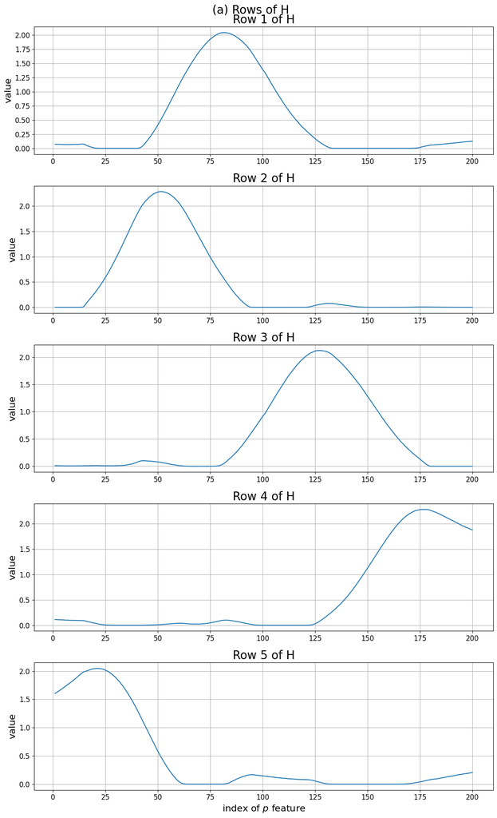

```python
# (a) For each j in 1, 2, ..., r, plot the j-th row of H against the index of p features
fig, axes = plt.subplots(r, 1, figsize=(12, 20))
x_axis_p = range(1, X_norm.shape[1] + 1)
for j in range(r):
    axes[j].plot(x_axis_p, H[j, :])
    axes[j].set(ylabel='value', title=f'Row {j+1} of H')
    axes[j].grid(True)
axes[-1].set_xlabel('index of $p$ feature')
fig.suptitle('(a) Rows of H')
fig.tight_layout()
plt.show()
```

The rows of H are the five components with temporal patterns learned by NMF, and each sample in X is approximated as an linear combination of these components with the coefficients in W.

From plot (a), each row of H has a local peak, but the peaks appear at different feature indices. This indicates that the five components capture neural activity concentrated in different time windows rather than a single common pattern.

In other words, NMF decompose the original data into several distinct components, each emphasising a different part of the 200-dimensional time series.

(b) Average $\mathbf{W}_{ij}$ over the sample indices i corresponding to the same brain region, and plot.

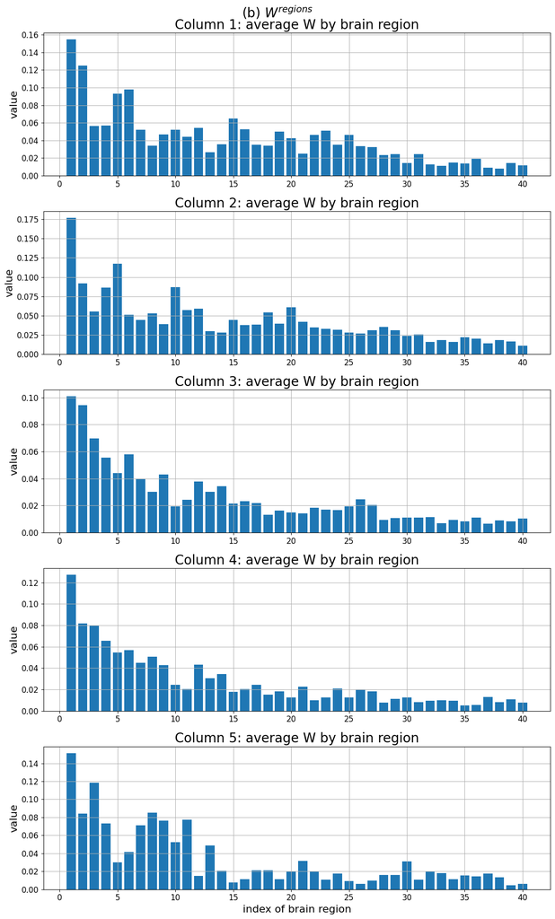

```python
# (b) Average W_ij over samples corresponding to the same brain region
fig, axes = plt.subplots(r, 1, figsize=(12, 20))
x_axis_region = range(1, N_Brain_Region + 1)
for j in range(r):
    W_regions = np.zeros(N_Brain_Region)
    for region in x_axis_region:
        # Calculate the mean of the specific brain region
        indices = (data['Brain Region Index'].values == region)
        W_regions[region - 1] = np.mean(W[indices, j])
    axes[j].bar(x_axis_region, W_regions)
    axes[j].set(title=f'Column {j+1}: average W by brain region', ylabel='value')
    axes[j].grid(True)
axes[-1].set_xlabel('index of brain region')
plt.suptitle('(b) $W^{regions}$')
plt.tight_layout()
plt.show()
```

$\mathbf{W}_{ij}$ is the coefficient of the j-th component of H to approximate $\mathbf{x}^{(i)}$. So for each component j, the average of weights over brain regions $\mathbf{W}^{\text{regions}}$ shows the importance of the component to each brain region.

Regions with high average values contribute more to the corresponding temporal component in H, while regions with low values contribute less. From the plots, some brain regions always have larger values than others, suggesting that the learned temporal patterns are more strong in these regions. For example, region 1 shows high value across all components, whereas regions with high indices, such as region 40, generally have much weaker contributions. In addition, some regions provide more contribution only to particular components, for instance, region 5 has relatively high values in Components 1 and 2 but much smaller values in Component 5, indicating that different regions are associated with different temporal patterns.

(c) Average $\mathbf{W}_{ij}$ over the sample indices i corresponding to the same trial, and plot.

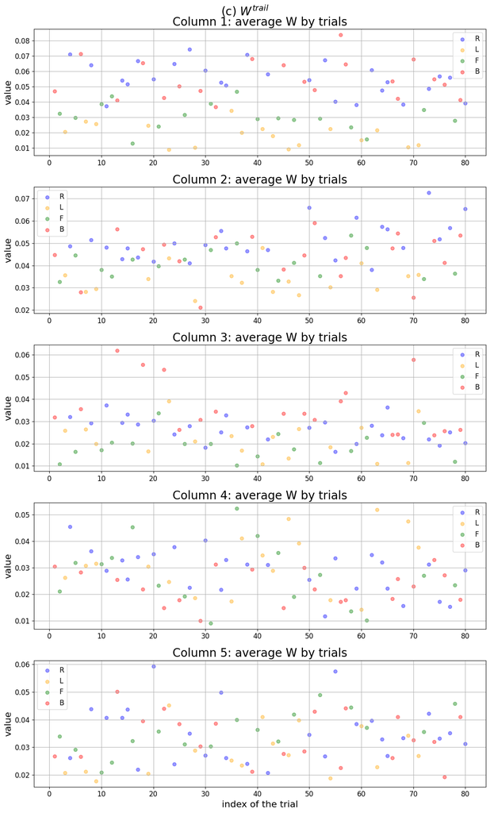

```python
# (c) Average W_ij over samples corresponding to the same trial
fig, axes = plt.subplots(r, 1, figsize=(12, 20))
x_axis_trial = range(1, N_Trial_Index + 1)

# Get trial type for each trial index
trial_types_unique = []
for trial in x_axis_trial:
    indices = (data['Trial Index'].values == trial)
    trial_types_unique.append(data['Trial Type'].values[indices][0])
trial_types_unique = np.array(trial_types_unique)

for j in range(r):
    W_trials = np.zeros(N_Trial_Index)
    for trial in x_axis_trial:
        # Calculate the mean of the specific trails
        indices = (data['Trial Index'].values == trial)
        W_trials[trial - 1] = np.mean(W[indices, j])

    for idx, trail_type in enumerate(class_labels):
        tt_mask = (trial_types_unique == idx)
        axes[j].scatter(np.where(tt_mask)[0] + 1, W_trials[tt_mask], alpha=0.4, c=colors[idx], label=trail_type)
    axes[j].set(title=f'Column {j+1}: average W by trials', ylabel='value')
    axes[j].grid(True)
    axes[j].legend()
axes[-1].set_xlabel('index of the trial')
plt.suptitle('(c) $W^{trail}$')
plt.tight_layout()
plt.show()
```

For each component j, the average of $\mathbf{W}_{ij}$ over trials $\mathbf{W}^{\text{trials}}$ shows the importance of the component to each trial.

For each trial, the coefficients differ across components, whcih means that each trial is expressed as a mixture of different temporal patterns. and for each trial types (R, L, F, B), the coefficient of each component is different but they usually locate at a similar height in the graph of each component, which means each trial type have similar temporal patterns in the data, but we cannot get more information from the plot since we have a very small test dataset and the variance is really big.

## (2.2) (index)

In this task we replace $\mathbf{\hat{X}}^{\text{NMF}}_{N\times p}$ by $\mathbf{\hat{X}}^{\text{NMTF}}_{N\times p} = \mathbf{U}_{N\times r_1} \mathbf{S}_{r_1\times r_2} (\mathbf{V}^T)_{r_2\times p}$

And we update the normalised squared Euclidean distance:

$$ \frac{\|\mathbf{X} - \mathbf{U} \mathbf{S} \mathbf{V}^T\|^2}{\|\mathbf{X}\|^2} $$

```python
def normalized_euclidean_cost_nmtf(X, U, S, V):
    """
    Computes the Normalied Euclidean NMF cost function.

    Parameters:
      X (np.ndarray): Data matrix, shape (N, p).
      U (np.ndarray): Weight matrix, shape (N, r_1).
      S (np.ndarray): Interaction matrix, shape (r_1, r_2).
      V (np.ndarray): Feature matrix, shape (p, r_2).

    Returns:
      cost_value (float): Value of the cost function.
    """
    # Check that U S V.T can be multiplied together
    assert U.shape[1] == S.shape[0], "The inner dimensions of U and S do not match for multiplication."
    assert S.shape[1] == V.shape[1], "The inner dimensions of S and V.T do not match for multiplication."

    # Test to see whether the size of X and the size of W times H matches
    assert X.shape == (U.shape[0], V.shape[0]), "The dimensions of X do not match the dimensions of U S V.T."

    # compute the difference between X and the matrix product of W and H
    diff = X - (U @ S @ V.T)## <-- SOLUTION

    numerator = np.sum(diff ** 2)
    denominator = np.sum(X ** 2)

    # Compute the Euclidean distance-baosed cost function
    cost_value = numerator / denominator## <-- SOLUTION

    return cost_value
```

multiplicative update rules: $$ U_{ij} \leftarrow U_{ij}\frac{(\mathbf{X}\mathbf{V}\mathbf{S}^{T})_{ij}}{(\mathbf{U}\mathbf{S}\mathbf{V}^{T}\mathbf{V}\mathbf{S}^{T})_{ij}} $$

$$ V_{kn} \leftarrow V_{kn}\frac{(\mathbf{X}^{T}\mathbf{U}\mathbf{S})_{kn}}{(\mathbf{V}\mathbf{S}^{T}\mathbf{U}^{T}\mathbf{U}\mathbf{S})_{kn}} $$

$$ S_{jn} \leftarrow S_{jn}\frac{(\mathbf{U}^{T}\mathbf{X}\mathbf{V})_{jn}}{(\mathbf{U}^{T}\mathbf{U}\mathbf{S}\mathbf{V}^{T}\mathbf{V})_{jn}} $$

```python
def euclidean_NMTF(X, r_1=7, r_2=5, rng=rng, epsilon=1e-7, n_iters=500):
  """
  Implements NMF with the euclidean cost function.

  Parameters:
    X (np.ndarray): Data matrix, shape (N, p).
    r_1 (int): Number of components.
    r_2 (int): Number of components.
    rng (np.random.default_rng): Random number generator.
    epsilon (float): Small positive scalar, default 0.0001.
    n_iters (int): Number of iterations, default 500.

  Returns:
    U (np.ndarray): Weight matrix, shape (N, r_1).
    S (np.ndarray): Feature matrix, shape (r_1, r_2).
    V (np.ndarray): Feature matrix, shape (p, r_2).
    cost_values (list): List of cost values for each iteration.
  """
  # U: N x r_1
  U = rng.random((X.shape[0], r_1))
  # S: r_1 x r_2
  S = rng.random((r_1, r_2))
  # V: p x r_2
  V = rng.random((X.shape[1], r_2))

  # empty list
  cost_values = []

  # loop over the n iterations
  for i in range(n_iters):
      # compute the update on U
      U = U * (X @ V @ S.T) / (U @ S @ V.T @ V @ S.T + epsilon)
      # compute the update on V
      V = V * (X.T @ U @ S) / (V @ S.T @ U.T @ U @ S + epsilon)
      # compute the update on S
      S = S * (U.T @ X @ V) / (U.T @ U @ S @ V.T @ V + epsilon)
      # compute the cost and append to list
      cost_values.append(normalized_euclidean_cost_nmtf(X, U, S, V))
      if i % 50 == 0 or i == n_iters - 1:
        print(f"Iteration {i:5d} | Loss: {normalized_euclidean_cost_nmtf(X, U, S, V):10.4e}")

  return U, S, V, cost_values
```

Train

```python
r_1, r_2 = 7, 5
U, S, V, cost_values_nmtf = euclidean_NMTF(X_norm)
```

```
Iteration     0 | Loss: 1.9396e-01
Iteration    50 | Loss: 1.0673e-01
Iteration   100 | Loss: 7.1552e-02
Iteration   150 | Loss: 5.0132e-02
Iteration   200 | Loss: 4.8035e-02
Iteration   250 | Loss: 4.7216e-02
Iteration   300 | Loss: 4.6420e-02
Iteration   350 | Loss: 4.0965e-02
Iteration   400 | Loss: 3.4004e-02
Iteration   450 | Loss: 3.2252e-02
Iteration   499 | Loss: 3.1507e-02
```

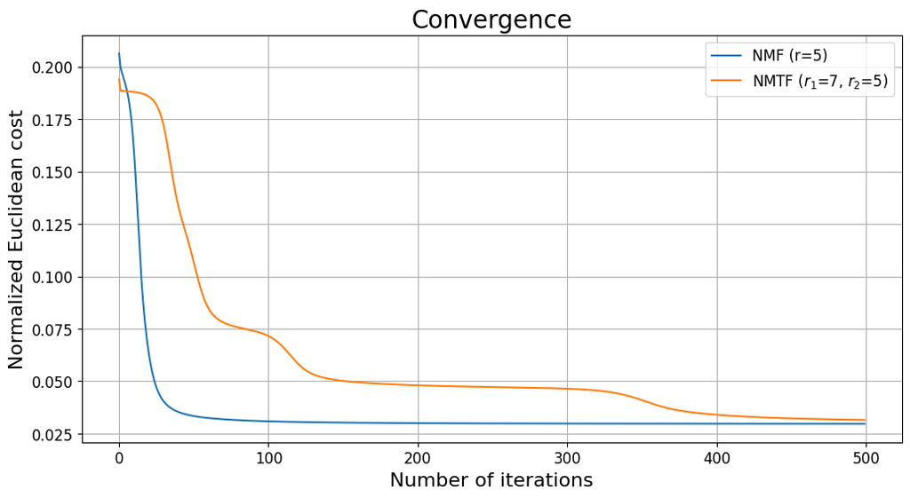

```python
# plotting the cost, to check convergence
fig, ax = plt.subplots(figsize=(12, 6))
ax.plot(cost_values_nmf, label='NMF (r=5)')
ax.plot(cost_values_nmtf, label=f'NMTF ($r_1$={r_1}, $r_2$={r_2})')
ax.set(title='Convergence', ylabel='Normalized Euclidean cost', xlabel='Number of iterations')
ax.legend()
ax.grid(True)
plt.show()
```

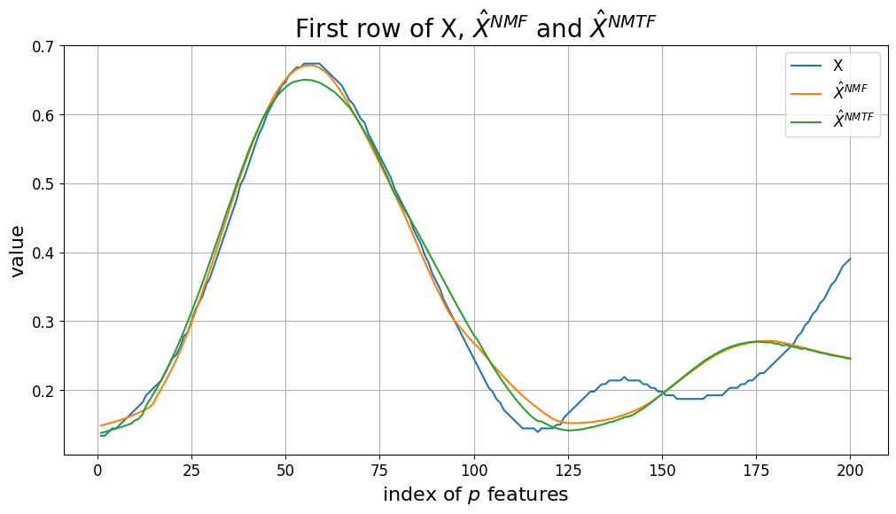

```python
# Visualise first row of X, X_NMF, X_NMTF
X_NMF = W @ H
X_NMTF = U @ S @ V.T

fig, ax = plt.subplots(figsize=(12, 6))
ax.plot(x_axis_p, X_norm[0, :], label='X')
ax.plot(x_axis_p, X_NMF[0, :], label=r'$\hat{X}^{NMF}$')
ax.plot(x_axis_p, X_NMTF[0, :], label=r'$\hat{X}^{NMTF}$')
ax.set(xlabel='index of $p$ features', ylabel='value', title=r'First row of X, $\hat{X}^{NMF}$ and $\hat{X}^{NMTF}$')
plt.legend()
plt.grid(True)
plt.show()
```

The comparison of the first row of X, NMF, NMTF shows that both methods capture the main overall shape of the signal, especially the largest peak(t=60). The NMF approximation follows the main peak more closely, while the NMTF approximation is smoother.

Both methods are less accurate in the final part of the series, where the original data vary more rapidly.

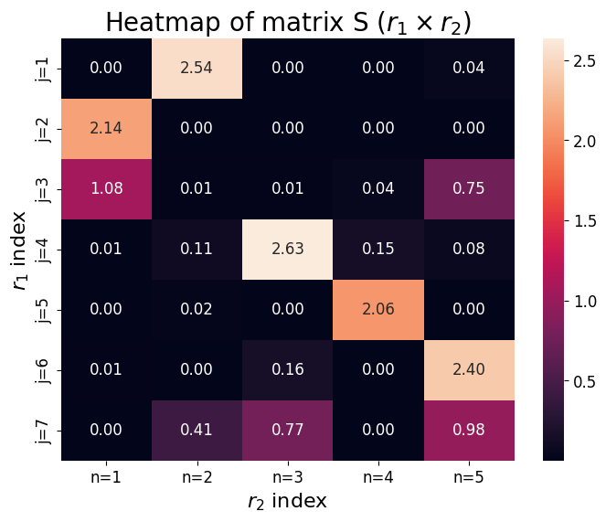

```python
# Heat map of S
fig, ax = plt.subplots(figsize=(8, 6))
sns.heatmap(S, annot=True, fmt='.2f', xticklabels=[f'n={n+1}' for n in range(r_2)], yticklabels=[f'j={j+1}' for j in range(r_1)])
ax.set(xlabel='$r_2$ index', ylabel='$r_1$ index', title='Heatmap of matrix S ($r_1 \\times r_2$)')
plt.show()
```

The heatmap of matrix S shows that only a few entries have large values. This suggests that specific pairs of components from U and V interact strongly, while many other interactions are ignored.

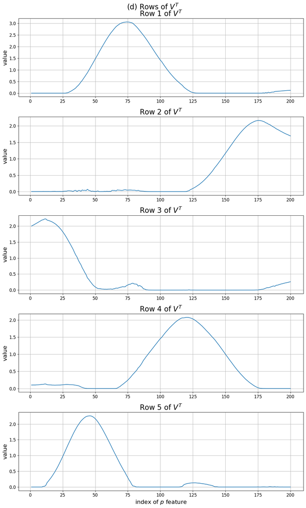

```python
# (d) For each n in 1, 2, ..., r, plot the n-th row of V.T against the index of p features
fig, axes = plt.subplots(r_2, 1, figsize=(12, 20))
x_axis_p = range(1, X_norm.shape[1] + 1)
for n in range(r_2):
    axes[n].plot(x_axis_p, V[:, n])
    axes[n].set(ylabel='value', title=f'Row {n+1} of $V^T$')
    axes[n].grid(True)
axes[-1].set_xlabel('index of $p$ feature')
fig.suptitle('(d) Rows of $V^T$')
fig.tight_layout()
plt.show()
```

Similar to NMF, the rows of $V^T$ are components that NMTF learnt in training, each is a p-dimentional vector. And from the graph, each row of $$V^T shows a local peak on the index of p features and each peak is at different position along the feature axis, which means that different components capture the information in different subsets of features.

The shape of each row is basicly the same with NMF, the only difference if the order of peaks in position, this is caused by different random initiation.

```python
# (e) find j that maximise S_jn
j_max_list = []
for n in range(r_2):
    j_max = np.argmax(S[:, n])
    j_max_list.append(j_max)
    print(f'(e) j with max S_j{n+1}: j = {j_max + 1} (S = {S[j_max, n]:.4f})')
```

```
(e) j with max S_j1: j = 2 (S = 2.1370)
(e) j with max S_j2: j = 1 (S = 2.5363)
(e) j with max S_j3: j = 4 (S = 2.6343)
(e) j with max S_j4: j = 5 (S = 2.0602)
(e) j with max S_j5: j = 6 (S = 2.4007)
```

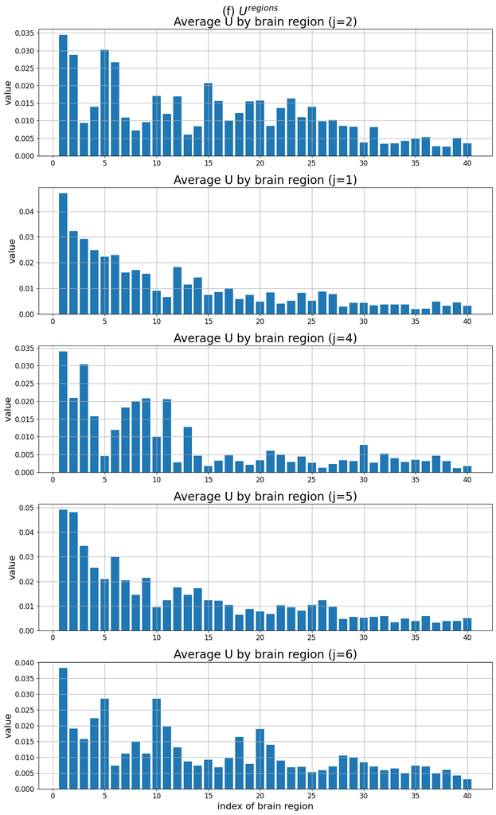

```python
# (f) Average U_ij over samples corresponding to the same brain region
fig, axes = plt.subplots(r_2, 1, figsize=(12, 20))
x_axis_region = range(1, N_Brain_Region + 1)
for idx, j in enumerate(j_max_list):
    U_regions = np.zeros(N_Brain_Region)
    for region in x_axis_region:
        # Calculate the mean of the specific brain region
        indices = (data['Brain Region Index'].values == region)
        U_regions[region - 1] = np.mean(U[indices, j])
    axes[idx].bar(x_axis_region, U_regions)
    axes[idx].set(title=f'Average U by brain region (j={j + 1})', ylabel='value')
    axes[idx].grid(True)
axes[-1].set_xlabel('index of brain region')
plt.suptitle('(f) $U^{regions}$')
plt.tight_layout()
plt.show()
```

For each $n$, selecting $j = \argmax_j S_{jn}$ gives the coefficient of $U$ that is most strongly associated with the n-th row in $V^T$. As in Task 2.1, larger values indicate stronger contributions from those regions to the corresponding temporal pattern.

Compared with NMF, the regional patterns are similar in the sense that lower-index brain regions contribute more, but in NMTF, the middle-index and even some the higher-index regions also remain a not low contribution.

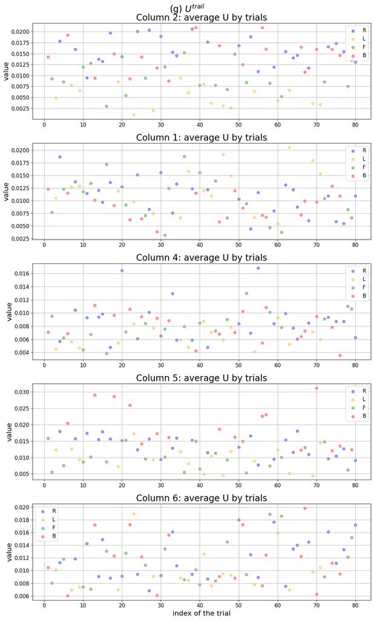

```python
# (g) Average U_ij over samples corresponding to the same trial
fig, axes = plt.subplots(r, 1, figsize=(12, 20))
x_axis_trial = range(1, N_Trial_Index + 1)

for idx, j in enumerate(j_max_list):
    U_trials = np.zeros(N_Trial_Index)
    for trial in x_axis_trial:
        # Calculate the mean of the specific trails
        indices = (data['Trial Index'].values == trial)
        U_trials[trial - 1] = np.mean(U[indices, j])

    for color_idx, trail_type in enumerate(class_labels):
        tt_mask = (trial_types_unique == color_idx)
        axes[idx].scatter(np.where(tt_mask)[0] + 1, U_trials[tt_mask], alpha=0.4, c=colors[color_idx], label=trail_type)
    axes[idx].set(title=f'Column {j+1}: average U by trials', ylabel='value')
    axes[idx].grid(True)
    axes[idx].legend()
axes[-1].set_xlabel('index of the trial')
plt.suptitle('(g) $U^{trail}$')
plt.tight_layout()
plt.show()
```

Similarly, the scatter plots in (g) show the contribution of the selected U components to the time patterns, with colours indicating trial type. And this graph also looks very silimar to the graph of NMF, but NMTF provides a more flexible factorisation because it gives two subspace which can describe two different patterns(V is the temporal pattern), and S controls the realtions of these two patterns.